# Tugas Individu Analisis Regresi

Rakesha Putra Antique Yusuf  
2024-03-05

```r
library(readxl)
library(tidyverse)
library(ggridges)
library(GGally)
library(plotly)
library(dplyr)
library(lmtest)
```

# Data

```r
data <- read_xlsx("C:/Users/RAKESHA/Downloads/Anreg Individu.xlsx")
```

## Eksplorasi Data

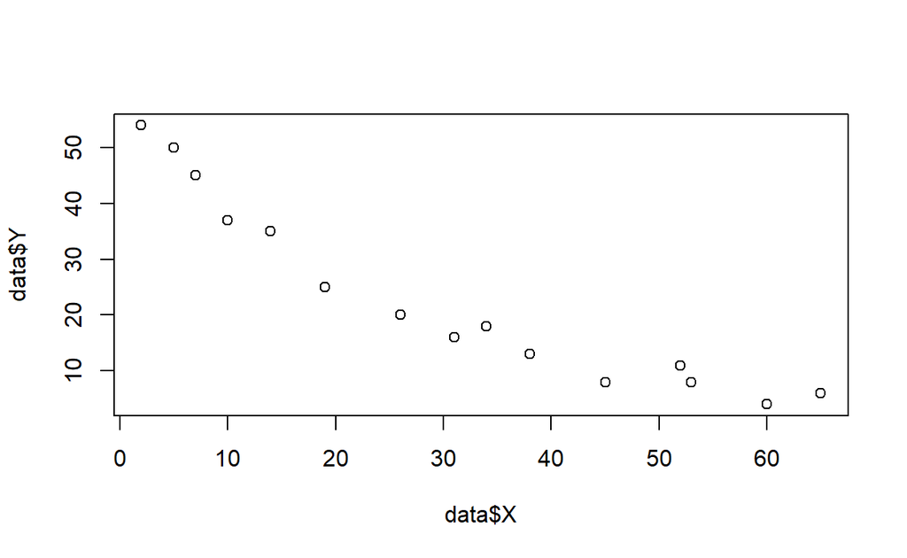

```r
plot(x = data$X, y = data$Y)
```

Dari scatter plot di atas menunjukan jika Y dan X tidak berhubungan liner

## Uji Normalitas

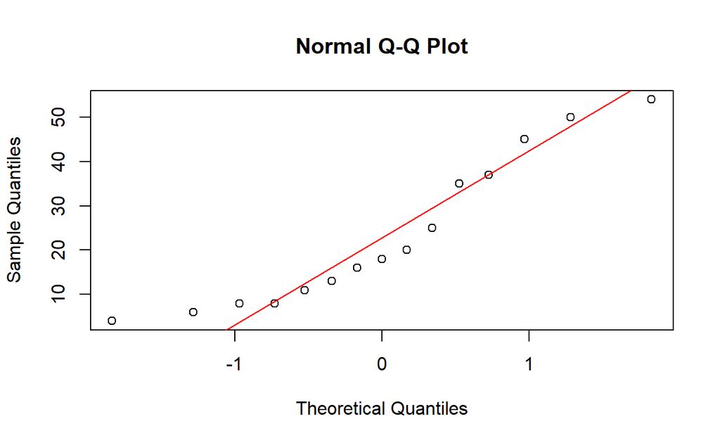

```r
qqnorm(data$Y)
qqline(data$Y, col = "red")
```

Data yang diketahui tidak menyebar normal

## Declare Model Regresi

```r
model_lm <- lm(formula = Y ~ X, data = data)
summary(model_lm)
```

```
Call:
lm(formula = Y ~ X, data = data)

Residuals:
    Min      1Q  Median      3Q     Max
-7.1628 -4.7313 -0.9253  3.7386  9.0446

Coefficients:
            Estimate Std. Error t value Pr(>|t|)
(Intercept) 46.46041    2.76218   16.82 3.33e-10 ***
X           -0.75251    0.07502  -10.03 1.74e-07 ***
---
Signif. codes:  0 '***' 0.001 '**' 0.01 '*' 0.05 '.' 0.1 ' ' 1

Residual standard error: 5.891 on 13 degrees of freedom
Multiple R-squared:  0.8856,    Adjusted R-squared:  0.8768
F-statistic: 100.6 on 1 and 13 DF,  p-value: 1.736e-07
```

```r
model_lm
```

```
Call:
lm(formula = Y ~ X, data = data)

Coefficients:
(Intercept)            X
    46.4604      -0.7525
```

## Uji Autokorelasi

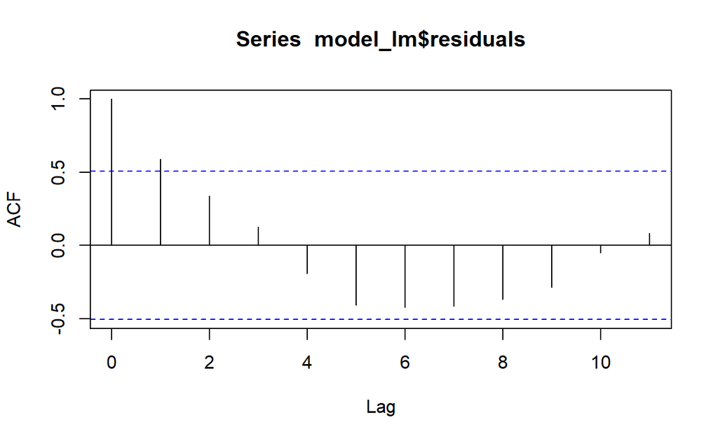

```r
acf(model_lm$residuals)
```

```r
dwtest(model_lm)
```

```
    Durbin-Watson test

data:  model_lm
DW = 0.48462, p-value = 1.333e-05
alternative hypothesis: true autocorrelation is greater than 0
```

Gambar tersebut menunjukkan adanya asumsi Gauss-Markov yang tidak terpenuhi, yaitu asumsi non-autokorelasi.

## Uji Homoskedastisitas

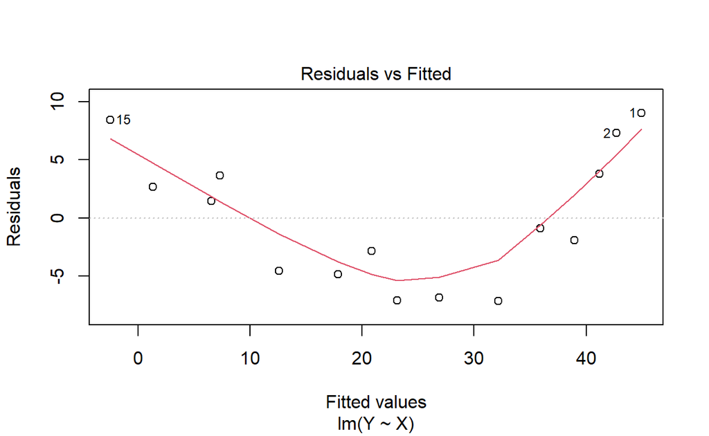

```r
plot(model_lm, which = 1)
```

## Transformasi

### WLS

Mencari nilai bobot:

```r
resid_abs <- abs(model_lm$residuals)
fitted_val <- model_lm$fitted.values
fit <- lm(resid_abs ~ fitted_val, data)
data.weights <- 1 / fit$fitted.values^2
data.weights
```

```
         1          2          3          4          5          6
0.03414849 0.03489798 0.03541143 0.03620311 0.03730067 0.03874425
         7          8          9         10         11         12
0.04091034 0.04257072 0.04361593 0.04507050 0.04779711 0.05077885
        13         14         15
0.05122749 0.05454132 0.05710924
```

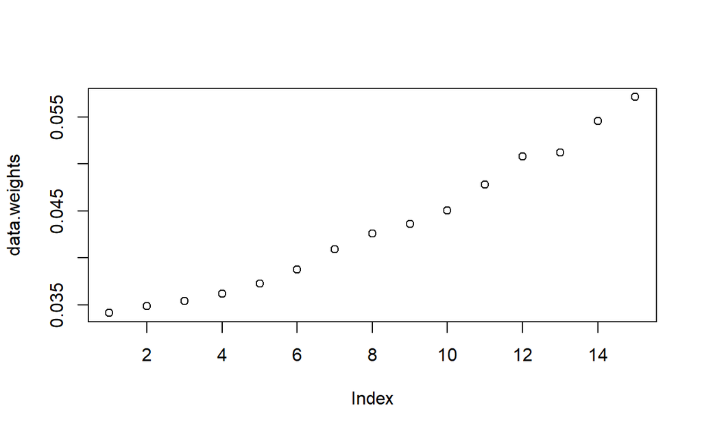

```r
plot(data.weights)
```

Hasil model regresi yang terboboti:

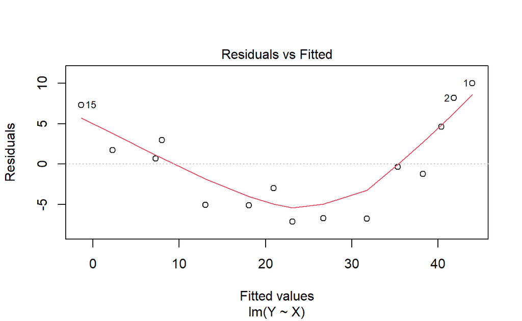

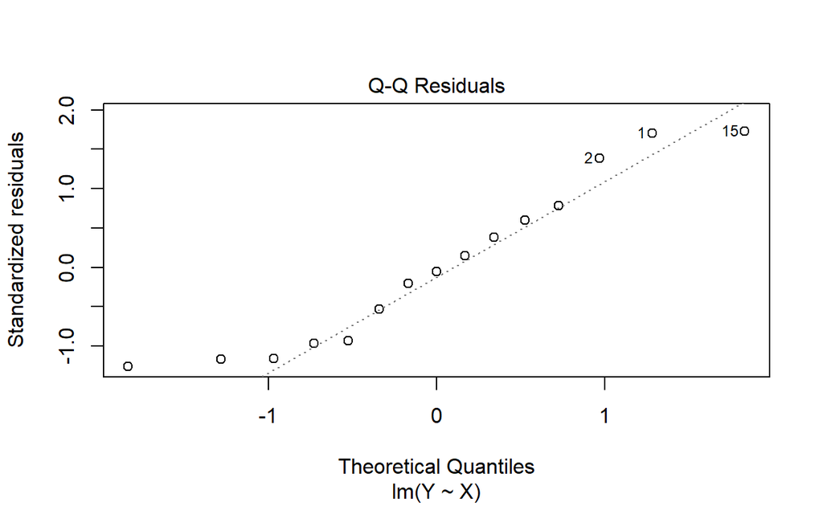

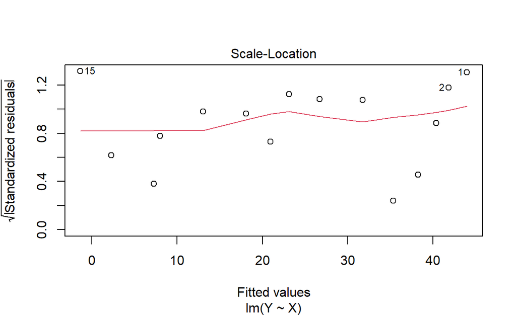

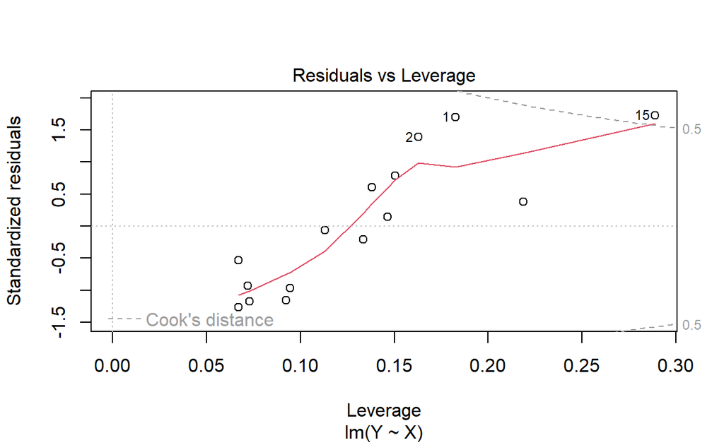

```r
model_weighted <- lm(Y~X, data = data, weights = data.weights)
plot(model_weighted)
```

```r
summary(model_weighted)
```

```
Call:
lm(formula = Y ~ X, data = data, weights = data.weights)

Weighted Residuals:
     Min       1Q   Median       3Q      Max
-1.46776 -1.09054 -0.06587  0.77203  1.85309

Coefficients:
            Estimate Std. Error t value Pr(>|t|)
(Intercept) 45.41058    2.90674  15.623 8.35e-10 ***
X           -0.71925    0.07313  -9.835 2.18e-07 ***
---
Signif. codes:  0 '***' 0.001 '**' 0.01 '*' 0.05 '.' 0.1 ' ' 1

Residual standard error: 1.204 on 13 degrees of freedom
Multiple R-squared:  0.8815,    Adjusted R-squared:  0.8724
F-statistic: 96.73 on 1 and 13 DF,  p-value: 2.182e-07
```

Dari hasil transformasi WLS di atas dapat disimpulkan WLS belum efektif dalam mentransformasi model regresi dapat dibuktikan dari hasil ekplorasi di atas masih belum memenuhi asumsi Gauss-Markov

### Transformasi Akar pada x, y, atau X dan y

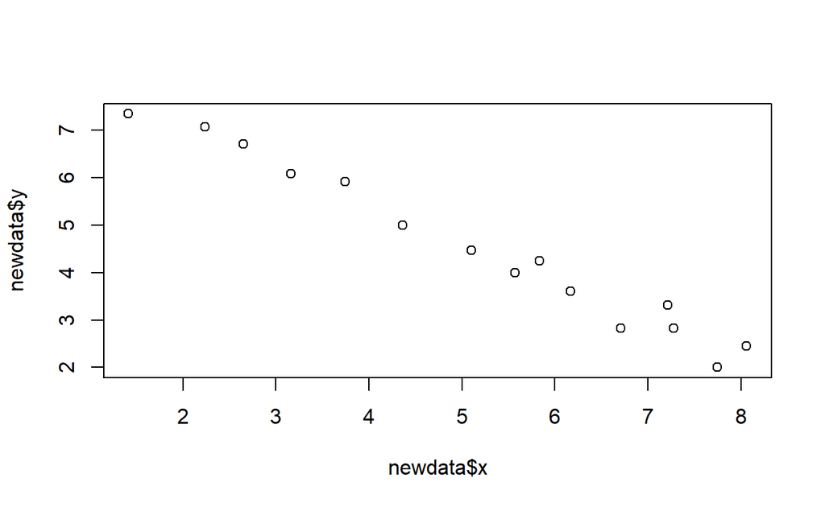

```r
newdata <- data %>%
  mutate(y = sqrt(Y)) %>%
  mutate(x = sqrt(X))
model_sqrt <- lm(y ~ x, data = newdata)
plot(x = newdata$x, y = newdata$y)
```

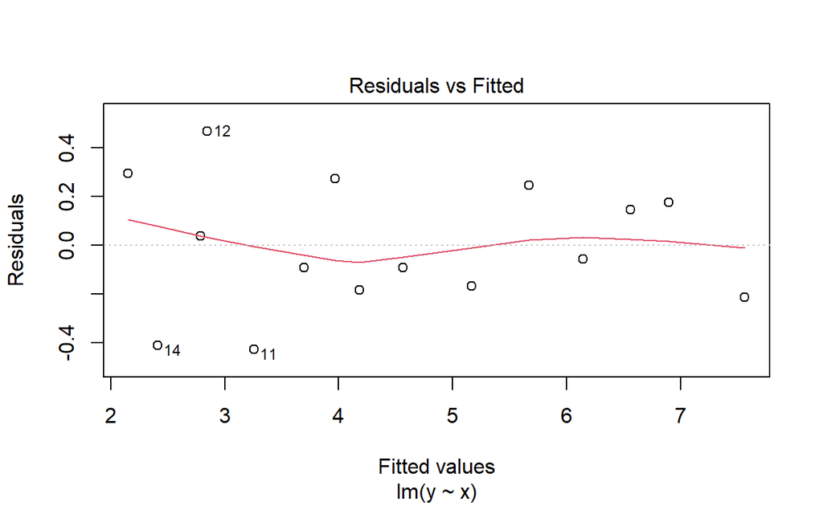

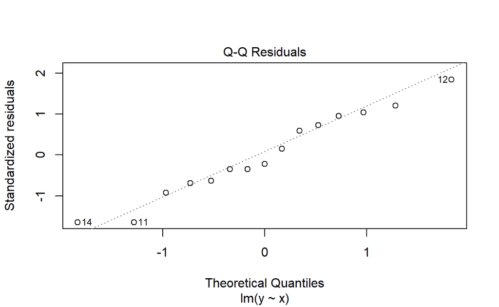

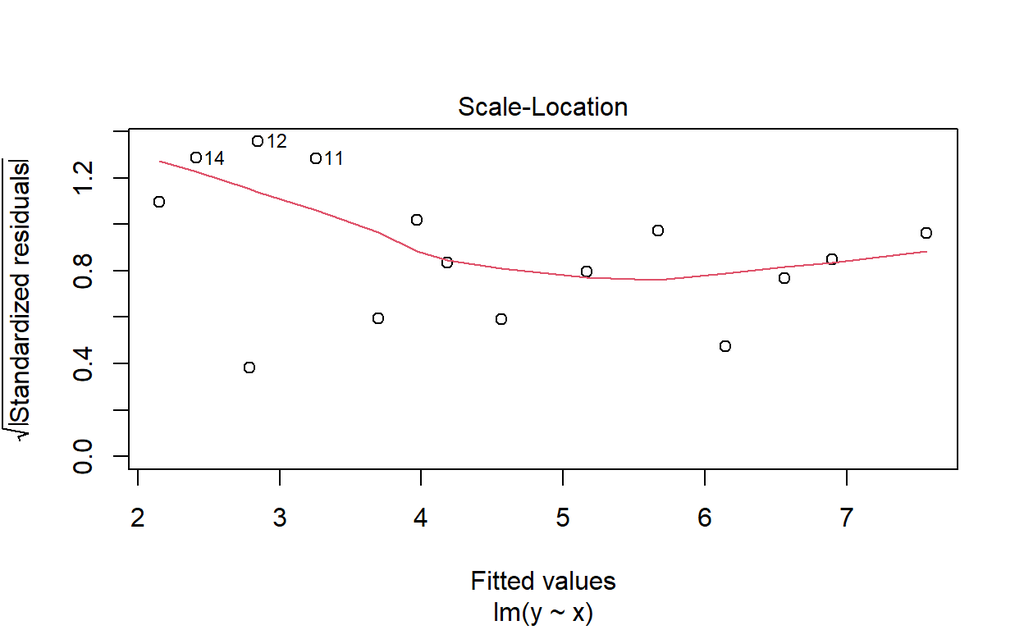

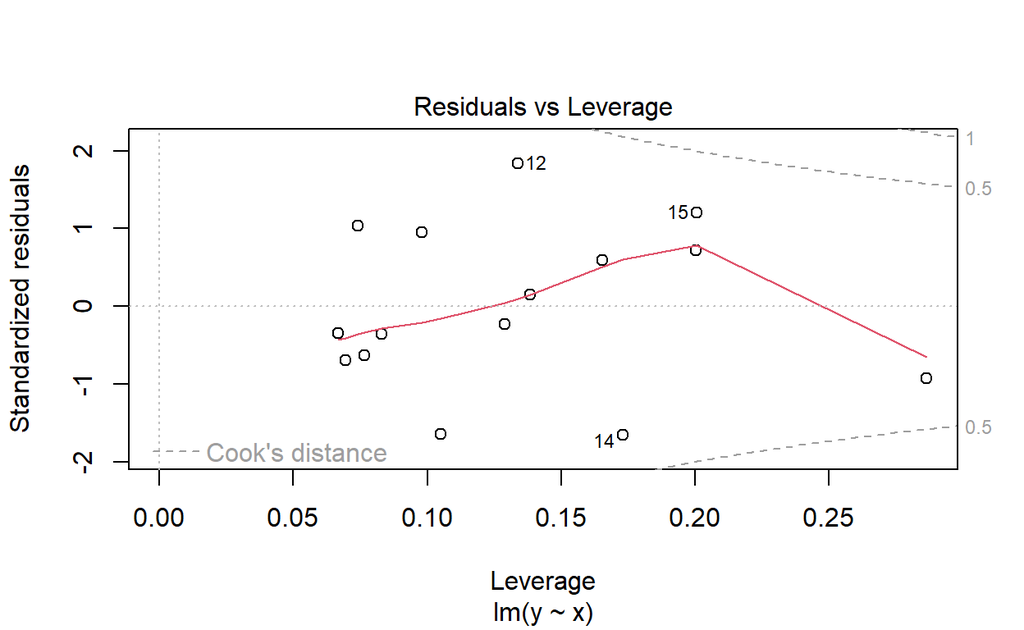

```r
plot(model_sqrt)
```

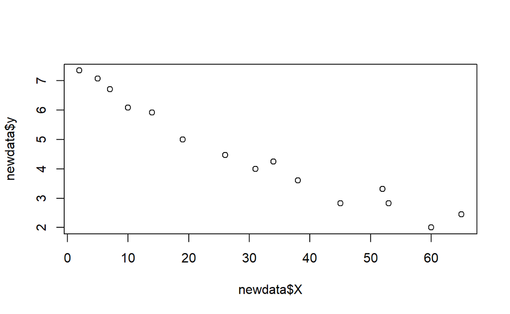

```r
model_sqrtx <- lm(y ~ X, data = newdata)
plot(x = newdata$X, y = newdata$y)
```

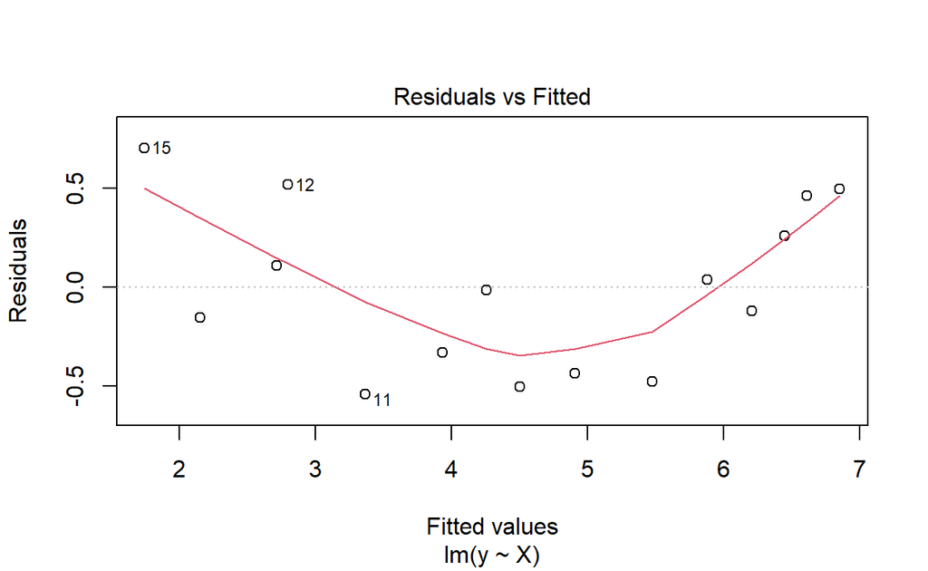

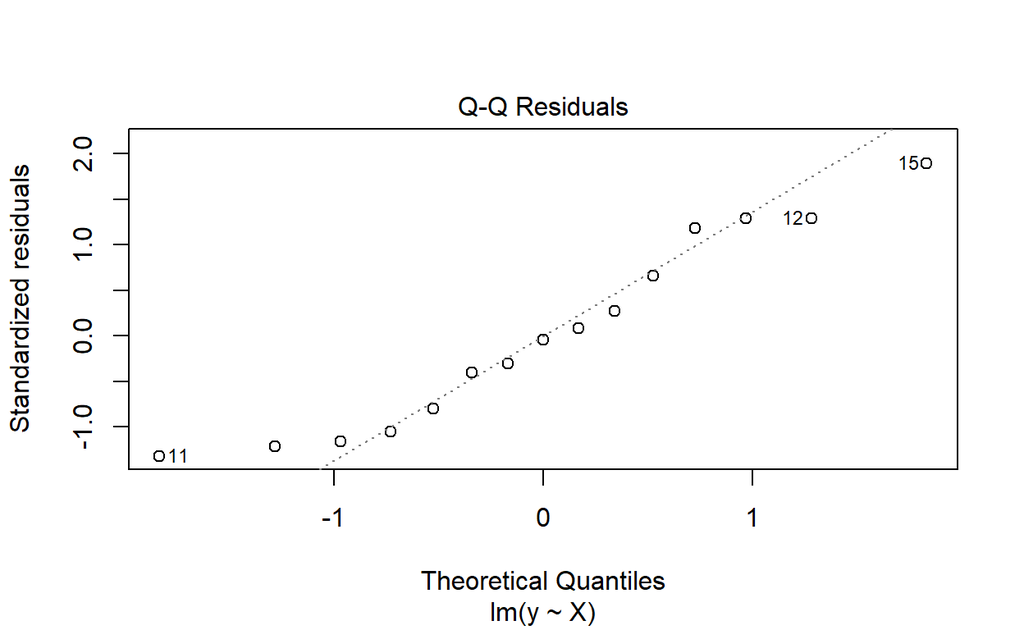

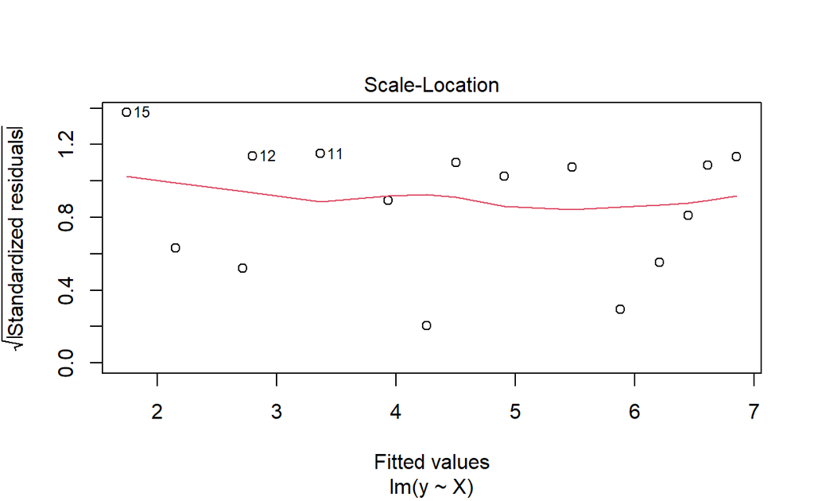

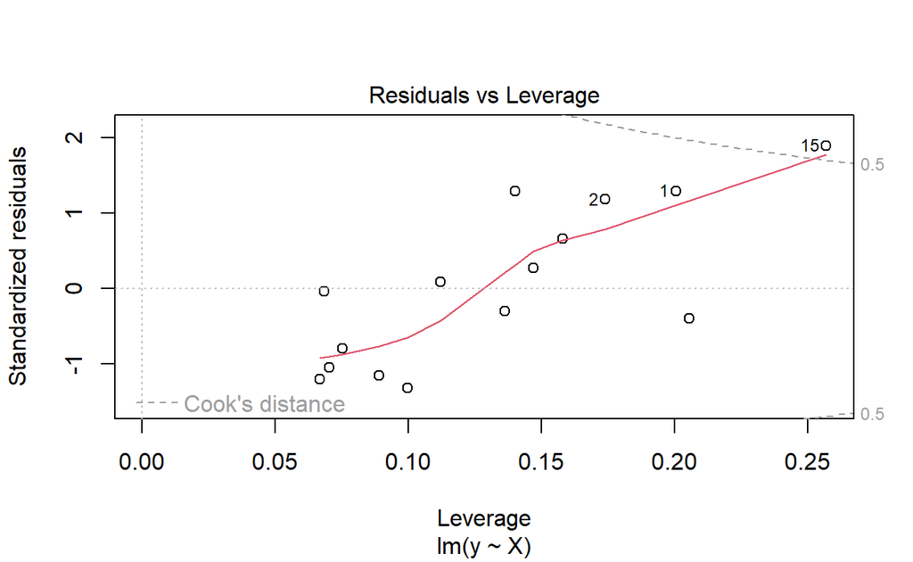

```r
plot(model_sqrtx)
```

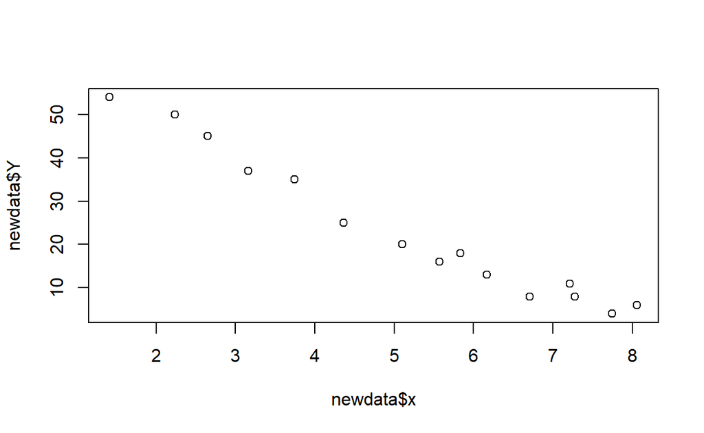

```r
model_sqrty <- lm(Y ~ x, data = newdata)
plot(x = newdata$x, y = newdata$Y)
```

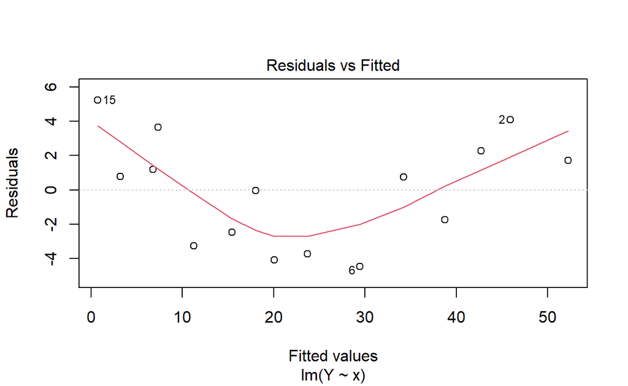

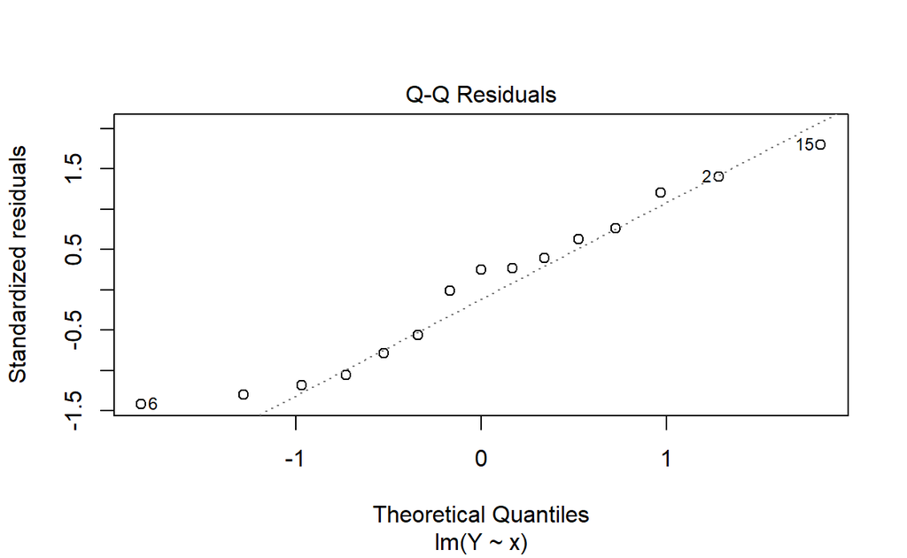

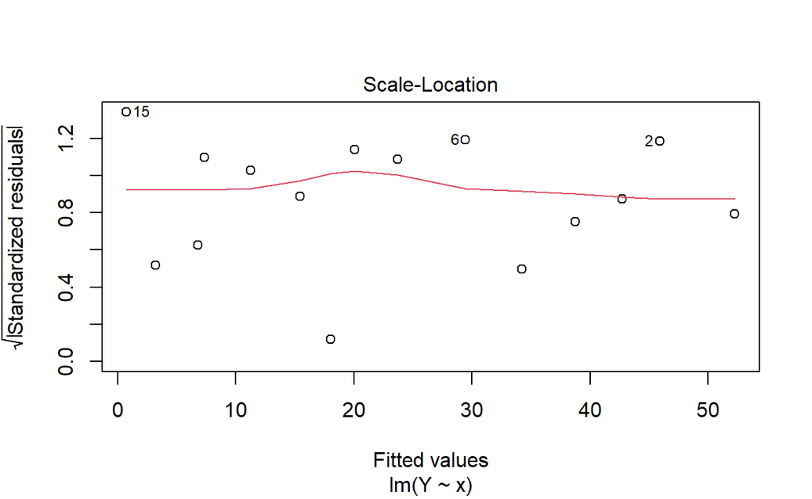

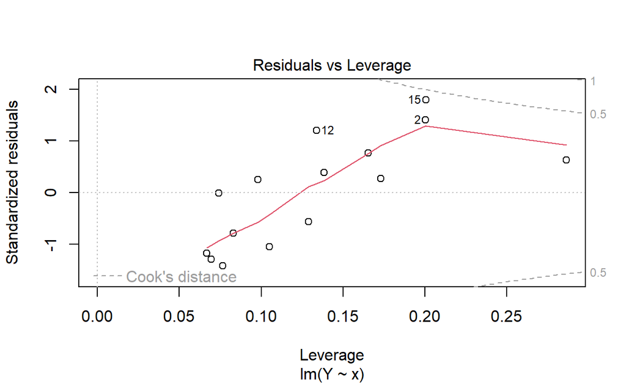

```r
plot(model_sqrty)
```

```r
summary(model_sqrt)
```

```
Call:
lm(formula = y ~ x, data = newdata)

Residuals:
     Min       1Q   Median       3Q      Max
-0.42765 -0.17534 -0.05753  0.21223  0.46960

Coefficients:
            Estimate Std. Error t value Pr(>|t|)
(Intercept)  8.71245    0.19101   45.61 9.83e-16 ***
x           -0.81339    0.03445  -23.61 4.64e-12 ***
---
Signif. codes:  0 '***' 0.001 '**' 0.01 '*' 0.05 '.' 0.1 ' ' 1

Residual standard error: 0.2743 on 13 degrees of freedom
Multiple R-squared:  0.9772,    Adjusted R-squared:  0.9755
F-statistic: 557.3 on 1 and 13 DF,  p-value: 4.643e-12
```

```r
summary(model_sqrtx)
```

```
Call:
lm(formula = y ~ X, data = newdata)

Residuals:
     Min       1Q   Median       3Q      Max
-0.53998 -0.38316 -0.01727  0.36045  0.70199

Coefficients:
             Estimate Std. Error t value Pr(>|t|)
(Intercept)  7.015455   0.201677   34.79 3.24e-14 ***
X           -0.081045   0.005477  -14.80 1.63e-09 ***
---
Signif. codes:  0 '***' 0.001 '**' 0.01 '*' 0.05 '.' 0.1 ' ' 1

Residual standard error: 0.4301 on 13 degrees of freedom
Multiple R-squared:  0.9439,    Adjusted R-squared:  0.9396
F-statistic: 218.9 on 1 and 13 DF,  p-value: 1.634e-09
```

```r
summary(model_sqrty)
```

```
Call:
lm(formula = Y ~ x, data = newdata)

Residuals:
    Min      1Q  Median      3Q     Max
-4.4518 -2.8559  0.7657  2.0035  5.2422

Coefficients:
            Estimate Std. Error t value Pr(>|t|)
(Intercept)  63.2250     2.2712   27.84 5.67e-13 ***
x            -7.7481     0.4097  -18.91 7.68e-11 ***
---
Signif. codes:  0 '***' 0.001 '**' 0.01 '*' 0.05 '.' 0.1 ' ' 1

Residual standard error: 3.262 on 13 degrees of freedom
Multiple R-squared:  0.9649,    Adjusted R-squared:  0.9622
F-statistic: 357.7 on 1 and 13 DF,  p-value: 7.684e-11
```

Dari hasil transformasi di atas dapat diambil kesimpulan jika transformasi akar membuat persamaan regresi menjadi lebih efektif akan tetapi dari hasil perbandingan x yang diakar, y yang diakar, atau keduanya yang diakar, model regresi yang x dan y-nya diakarkan lebih baik dibanding 2 lainnya. Hal tersebut terbukti dari R-Square dan Adjusted R-squared yang paling tinggi dengan nilai 0.9772 dan 0.9755.